# index

**BribeR** is an R package for accessing and analyzing text transcript data from the *Vladivideos,* covert recordings documenting bribery and corruption during Alberto Fujimori’s presidency in Peru (1990-2000).

This package provides user-friendly access to a large digital archive of *Vladivideo* transcripts and metadata, including data about 125 individual speakers in the files and 15 expert-coded topics of importance during the Fujimori presidency.

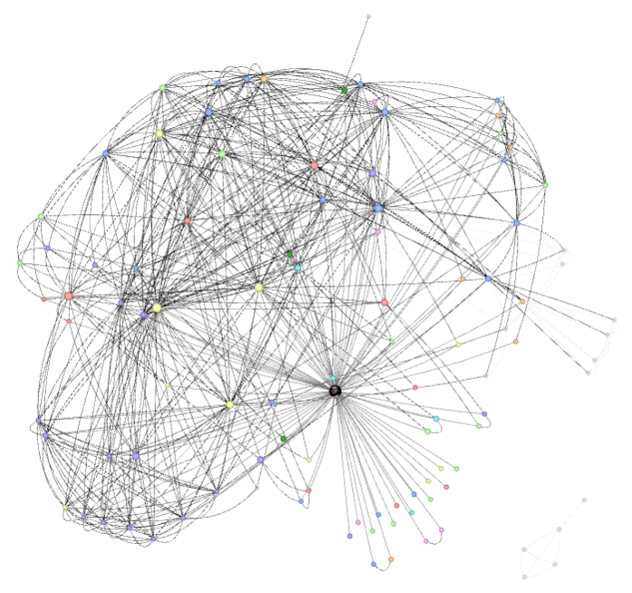

Speakers recorded in the *Vladivideo* files, with Montesinos in the center. See [Network Visualization](https://jessietrudeau.com/BribeR/articles/transcript_network_app.html) for more details.

## Installation

To install the package in your console, run one of the two below commands:

```r
# Install from CRAN
install.packages("BribeR")

# Or install the development version from GitHub
# install.packages("remotes")
remotes::install_github("jessietrudeau/BribeR")
```

## Core Functions

This package provides three families of functions to access, organize, and analyze *Vladivideo* data. For a full online guide, see the [BribeR User Guide](https://jessietrudeau.com/BribeR/articles/using_briber.html).

**1. Read transcripts**

These functions load transcript data as tibbles or load original source .csv files.

**2. Find transcripts**

These functions allow the user to filter transcripts by specific speakers, topics, or transcript ID numbers.

**3. Integrate with transcript metadata**

These functions allow the user to find metadata and combine it with transcripts or their speakers.

## Basic Usage

The syntax of `BribeR` is designed to help users easily find and download transcripts relevant to their interest. For example, a user interested in obtaining transcript text data and metadata about all conversations involving **media manipulation** would run the following lines of code:

```r
# Load data
library(BribeR)

# Find specific transcripts about media manipulation
media_ids <- get_transcript_id(topic = "media")

# Get the metadata summary of the transcripts about media manipulation
meta <- read_transcript_meta_data(media_ids)

# Load full-text transcripts about media manipulation
media_transcripts <- read_transcripts(media_ids)
```

## Datasets

BribeR includes four datasets:

| Dataset | Description |
| --- | --- |
| `compiled_transcripts` | Full text corpus: 47,375 speech turns across 101 transcripts |
| `transcript_index` | Wide-format transcript-level metadata with dates and summaries, and searchable by speaker and topic |
| `speakers_per_transcript` | Speaker roster per transcript |
| `actors` | Actor-level metadata, including industry and a short description |

A full description of the raw data is in the [Raw Data Guide](https://jessietrudeau.com/BribeR/articles/raw_data_guide.html), as well as a description of additional actor- and topic-level metadata accessible in **BribeR.** A full description of the datasets included in the package is in the [BribeR Data Guide](https://jessietrudeau.com/BribeR/articles/briber_data_guide.html).

## Contributing

Contributions are welcome. Please create a new branch for a feature, to open an issue, or for a pull request on [GitHub](https://github.com/jessietrudeau/BribeR/issues).

Document exported functions with roxygen2 comments. Add or update tests in tests/testthat/.

## Credits

All *Vladivideo* transcript data included in this package are drawn from publicly available materials, including print volumes published by the Peruvian Truth and Reconciliation Commission (*Comisión de la Verdad e Reconciliación*) and online Congressional archives from [LUM/CDI](https://lum.cultura.pe/cdi/busqueda/colecciones?field_coleccion=55&field_palabra_clave%5B%5D=13462&field_year=) (*Lugar de la Memoria, la Tolerancia y la Inclusión Social*), the Ministry of Culture’s Place of Memory, Tolerance, and Social Inclusion. In accordance with LUM’s guidance, we understand these official documentary materials to fall outside copyright protection under Article 9(b) of Peru’s [Legislative Decree No. 822](https://www.leyes.congreso.gob.pe/Documentos/DecretosLegislativos/00822.pdf), which excludes official legislative, administrative, and judicial texts, since the original entity that provided the *Vladivideo* data was the Congress of the Republic of Peru.

This research was generously supported by Syracuse University’s [Open Source Program Office](https://opensource.syracuse.edu/%22) (OSPO) and the Sloan Foundation.

## Citation

If you use **BribeR** in your research, please cite it as:

> Trudeau, Jessie, and Soto Plaza, Andrés. 2026. *BribeR: Tools for Analyzing Vladivideo Transcript Data*. R package version 0.1.0. https://github.com/jessietrudeau/BribeR